# Bimodality analysis of Höechst accumulation and degradation distribution in E.coli

### 1. Dataset introduction

The followings are dataset of Höechst (HT) fluorescent intensity for individual E.coli cells. They were collected from 2 types of experimental protocols: accumulation and degradation. HT was treated for 2 different E.coli strains : wild type (WT) and tolC-/- (DTolC). tolC is required for the assembly of efflux pump in bacterial cell. Deleting tolC impairs activity of efflux pump, and therefore efflux. ##### 1.1. HT accumulation In order to measure the kinetics of HT accumulation, exponentially grown E.coli cells were treated with different concentrations of HT. Aliquots of treated cells were taken from a shaking culture periodically then transferred to 1.5% agarose pad containing corresponding HT concentrations, and observed under fluorescent microscope. ##### 1.2. HT degradation Exponentially grown E.coli cells were treated with different concentrations of HT for at least 1h. At OD600~0.1, cells were centrifuged and transferred to fresh media with no HT. Aliquots were taken from this culture (with shaking) periodically then transferred to 1.5% agarose pad with no HT and observed under fluorescent microscope. ##### 1.3. Image processing Fluorescent images were analyzed with MicrobeJ plug-in for Fiji. Output information was collected and organized in tabular format as can be seen below. ### 2. Data processing 2.1. Load libraries

```r
library(plyr)
library(tidyverse)
library(dplyr)
library(data.table)
```

```r
library(ggplot2)
library(stats)
library(sparklyr)
library(readxl)
library(plotly)
library(openxlsx)
library(gridExtra)
library(ggprism)
library(scales)
library(emojifont)
library(Cairo)
library(ggnewscale)
library(stats)
library(clValid)
library(mclust)
library(tidymodels)
library(patchwork)
library(varrank)
library(infotheo)
library(discretization)
library(arc)
library(entropy)
library(actuar)
library(ordinal)
library(devtools)
library(ggbiplot)
library(caret)
library(corrplot)
library(betareg)
library(leaps)
library(MASS)
library(moments)
library(microbiome)
library(diptest)
```

2.2. Download data from cloud storage and parse to dataframes

```r
#Links to csv files

url1 <- "https://www.dropbox.com/s/ic053m6xixmag5t/HT_degradation_demo.csv?dl=1"
url2 <- "https://www.dropbox.com/s/di568r38yhduavw/HT_accumulation_demo.csv?dl=1"
url3 <- "https://www.dropbox.com/s/lbgizq7mn0hqha1/ClusterHT.csv?dl=1"
url4 <- "https://www.dropbox.com/s/9vi4fj7h97ugzk7/20211127_H342_degradation_snapshot_old.csv?dl=1"
# Read and parse to dataframe
df_deg <- fread(url1) # Data for degradation
df_deg.old <- fread(url4)
df_acc <- fread(url2) # Data for accumulation
# Check available columns
colnames(df_deg)
```

```
##  [1] "IMAGE"                 "INTENSITY"             "INTENSITY.ch2.mean_c"
##  [4] "LOCATION"              "Time_m"                "normed_intensity_ch2"
##  [7] "Exposure_time"         "HT_Conc_uM"            "Genotype"
## [10] "Strain"                "Media"                 "Final_OD600"
## [13] "Protocol"              "Date_and_growth_curve" "Phenotype"
## [16] "Repeat"
```

```r
colnames(df_acc)
```

```
##  [1] "IMAGE"                 "INTENSITY"             "INTENSITY.ch2.mean_c"
##  [4] "LOCATION"              "Time_m"                "normed_intensity_ch2"
##  [7] "Exposure time"         "HT_Conc_uM"            "Genotype"
## [10] "Strain"                "Media"                 "Final_OD600"
## [13] "Initial_OD600"         "Protocol"              "Date_and_growth_curve"
## [16] "Phenotype"             "Repeat"                "V18"
## [19] "V19"                   "V20"                   "V21"
## [22] "V22"                   "V23"                   "V24"
## [25] "V25"                   "V26"                   "V27"
## [28] "V28"                   "V29"                   "V30"
## [31] "V31"                   "V32"                   "V33"
## [34] "V34"                   "V35"
```

2.3. Data wrangling

```r
# Subset necessary columns
df1 <- subset(df_acc ,select = c( Genotype,
                                   HT_Conc_uM,
                                   Repeat,
                                   Time_m,
                                   normed_intensity_ch2
                                    ))
df2 <- subset(df_deg, select = c( Genotype,
                                   HT_Conc_uM,
                                   Repeat,
                                   Time_m,
                                   normed_intensity_ch2 ))
df3 <- subset(df_deg.old , select =c( Genotype,
                                   HT_Conc_uM,
                                   Repeat,
                                   Time_m,
                                   normed_intensity_ch2 ) )
df_acc <- df_acc[order(df_acc$HT_Conc_uM,df_acc$Time_m),]
df_deg <- df_deg[order(df_deg$HT_Conc_uM,df_deg$Time_m),]
df_deg.old <- df_deg.old[order(df_deg.old$HT_Conc_uM,df_deg.old$Time_m),]
# Parse HT accumulation with WT cells data for timepoints >0  into a separate dataframe
df_acc.WT <- df1[((df1$Time_m > 0) &
                   (df1$Genotype == "WT")),]
# Order HT_Conc_uM and Time_m columns
df_acc.WT <- df_acc.WT[order(df_acc.WT$HT_Conc_uM,df_acc.WT$Time_m),]
# Parse HT accumulation with DTolC cells data for timepoints >0  into a separate dataframe
# Order HT_Conc_uM and Time_m columns
df_acc.DTolC <- df1[((df1$Time_m > 0) &
                   (df1$Genotype == "DTolC") ),]
df_acc.DTolC <- df_acc.DTolC [order(df_acc.DTolC$HT_Conc_uM,df_acc.DTolC$Time_m),]
# Parse HT degradationwith WT cells data for timepoints >=0  into a separate dataframe
df_deg.WT <- df2[((df2$Time_m >= 0) &
                   (df2$Genotype == "WT") ),]
# Order HT_Conc_uM and Time_m columns
df_deg.WT <- df_deg.WT[order(df_deg.WT$HT_Conc_uM,df_deg.WT$Time_m),]
# Parse HT degradationwith DTolC cells data for timepoints >=0  into a separate dataframe
df_deg.DTolC <- df3[((df3$Time_m >= 0) &
                   (df3$Genotype == "DTolC") ),]
# Order HT_Conc_uM and Time_m columns
df_deg.DTolC <- df_deg.DTolC[order(df_deg.DTolC$HT_Conc_uM,df_deg.DTolC$Time_m),]
df_deg.WTa <- df3[((df3$Time_m >= 0) &
                   (df3$Genotype == "WT") ),]
# df_deg.WTa <- df_deg.WTa[order(df_deg.WTa$HT_Conc_uM,df_deg.WTa$Time_m),]
# df_deg.WT <-bind_rows(df_deg.WT,df_deg.WTa)
```

### 3. Data exploration

3.1. Probability distribution of HT accumulation kinetics in WT cells

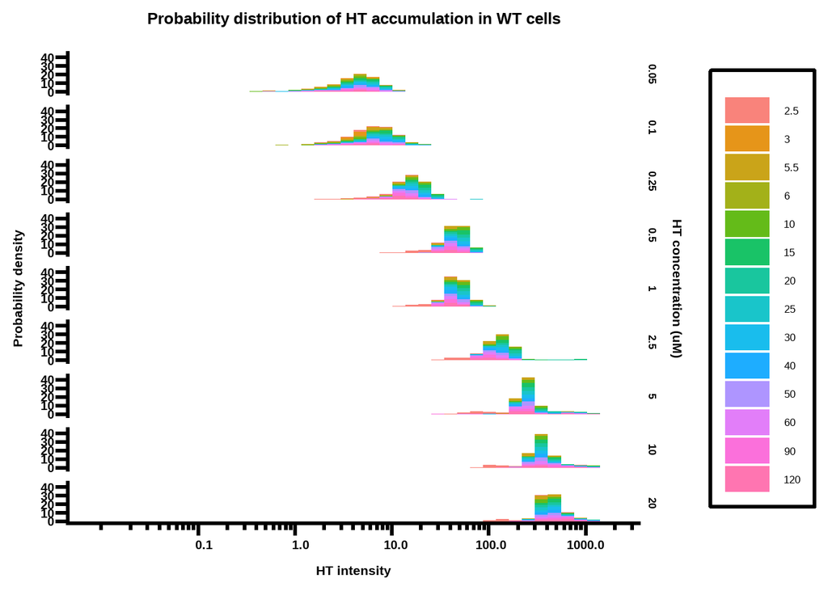

```r
tval <- sort( as.vector(sapply(seq(1 , 9) , function(x)  x*10^seq(-2 ,3))))
ttxt <- rep( "" , length(tval))
ttxt [seq(1,37,9)] <- as.character(tval)[seq(1,37,9)]
p.acc.dist <- ggplot(df_acc.WT) +
                            ggnewscale::new_scale_color() +
                             geom_histogram(aes(x= normed_intensity_ch2,
                                                                        y = after_stat(density),
                                                                        fill = as.factor(Time_m)),
                                                                bins = 40,
                                                                alpha = 0.9) +
                            facet_grid(rows = vars(HT_Conc_uM)) +
                            scale_color_prism(palette = "prism_dark") +
                            scale_y_continuous(name = "Probability density") +
                            scale_x_log10(name = "HT intensity",
                                                        guide = 'prism_minor',
                                                         minor_breaks = tval,
                                                        breaks = c(0.1,1,10,100,1000),
                                                        labels =function(n){format(n, scientific = FALSE)})+
                            labs (title = "Probability distribution of HT accumulation in WT cells")+
                            guides(fill= guide_legend(title = "Time (m)"),
                                            y.sec = guide_none("HT concentration (uM)")) +
                            theme_prism(palette = "prism_dark",
                                                        base_size = 16) +
                            theme(legend.background = element_rect(fill = "white"))
p.acc.dist
```

3.2. Probability distribution of HT degradation kinetics in WT cells

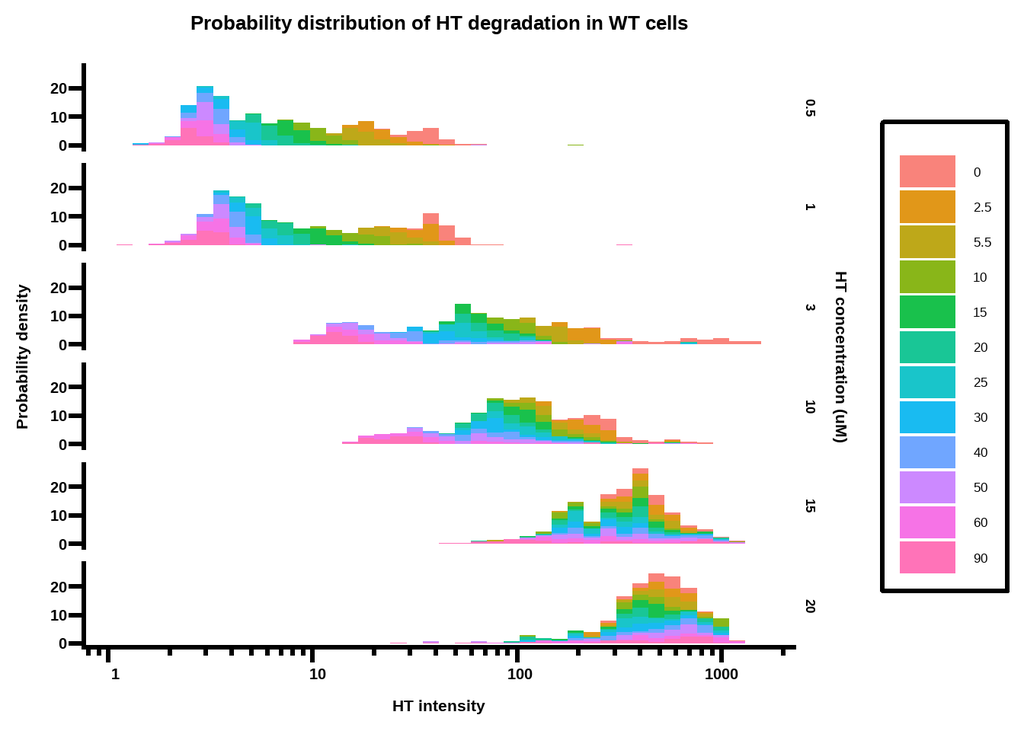

```r
p.deg.dist <- ggplot(df_deg.WT) +
                            ggnewscale::new_scale_color() +
                             geom_histogram(aes(x= normed_intensity_ch2,
                                                                        y = after_stat(density),
                                                                        fill = as.factor(Time_m)),
                                                                bins = 40,
                                                                alpha = 0.9) +
                            facet_grid(rows = vars(HT_Conc_uM)) +
                            scale_color_prism(palette = "prism_dark") +
                            scale_y_continuous(name = "Probability density") +
                            scale_x_log10(name = "HT intensity",
                                                        guide = 'prism_minor',
                                                         minor_breaks = tval,
                                                        breaks = c(0.1,1,10,100,1000),
                                                        labels =function(n){format(n, scientific = FALSE)})+
                            labs (title = "Probability distribution of HT degradation in WT cells")+
                            guides(fill= guide_legend(title = "Time (m)"),
                                            y.sec = guide_none("HT concentration (uM)")) +
                            theme_prism(palette = "prism_dark",
                                                        base_size = 16) +
                            theme(legend.background = element_rect(fill = "white"))
p.deg.dist
```

From the histograms of HT intensity distribution for degradation and accumulation kinetics, it is evident that HT degradation creates a more heterogeneous response in WT cells. There might be potentially a bimodal distribution in the case of HT degradation kinetics.

3.4. Probability distribution of HT degradation kinetics in tolC-/- cells

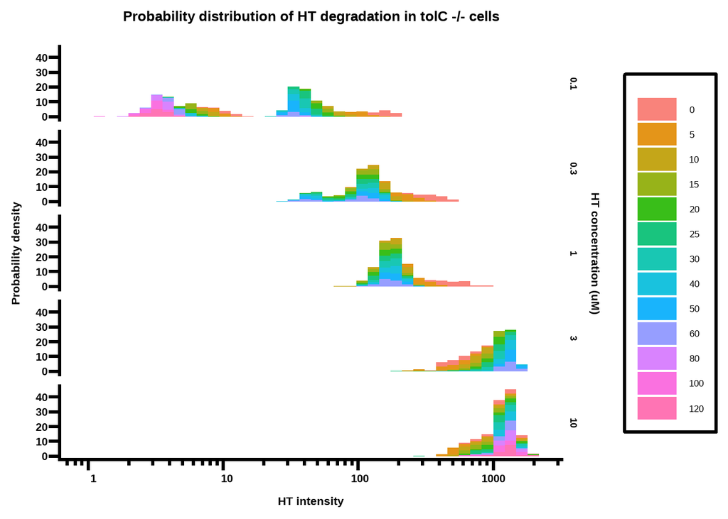

```r
p.deg.tolc <- ggplot(df_deg.DTolC) +
                            ggnewscale::new_scale_color() +
                             geom_histogram(aes(x= normed_intensity_ch2,
                                                                        y = after_stat(density),
                                                                        fill = as.factor(Time_m)),
                                                                bins = 40,
                                                                alpha = 0.9) +
                            facet_grid(rows = vars(HT_Conc_uM)) +
                            scale_color_prism(palette = "prism_dark") +
                            scale_y_continuous(name = "Probability density") +
                            scale_x_log10(name = "HT intensity",
                                                        guide = 'prism_minor',
                                                         minor_breaks = tval,
                                                        breaks = c(0.1,1,10,100,1000),
                                                        labels =function(n){format(n, scientific = FALSE)})+
                            labs (title = "Probability distribution of HT degradation in tolC -/- cells")+
                            guides(fill= guide_legend(title = "Time (m)"),
                                            y.sec = guide_none("HT concentration (uM)")) +
                            theme_prism(palette = "prism_dark",
                                                        base_size = 16) +
                            theme(legend.background = element_rect(fill = "white"))
p.deg.tolc
```

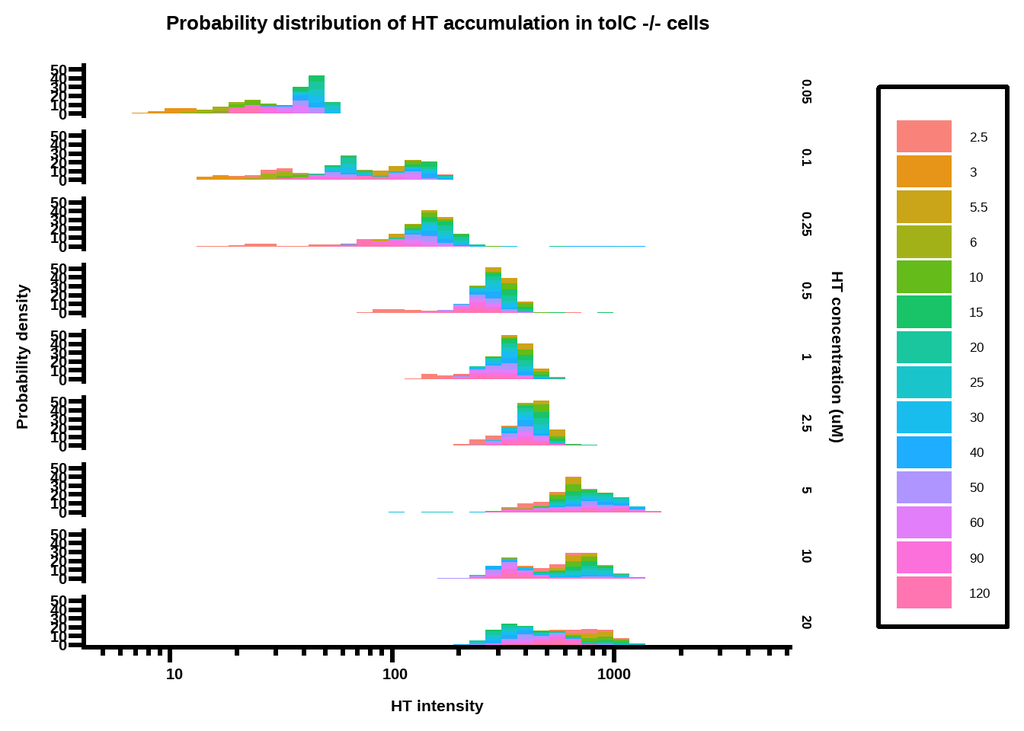

```r
p.acc.tolc <- ggplot(df_acc.DTolC) +
                            ggnewscale::new_scale_color() +
                             geom_histogram(aes(x= normed_intensity_ch2,
                                                                        y = after_stat(density),
                                                                        fill = as.factor(Time_m)),
                                                                bins = 40,
                                                                alpha = 0.9) +
                            facet_grid(rows = vars(HT_Conc_uM)) +
                            scale_color_prism(palette = "prism_dark") +
                            scale_y_continuous(name = "Probability density") +
                            scale_x_log10(name = "HT intensity",
                                                        guide = 'prism_minor',
                                                         minor_breaks = tval,
                                                        breaks = c(0.1,1,10,100,1000),
                                                        labels =function(n){format(n, scientific = FALSE)})+
                            labs (title = "Probability distribution of HT accumulation in tolC -/- cells")+
                            guides(fill= guide_legend(title = "Time (m)"),
                                            y.sec = guide_none("HT concentration (uM)")) +
                            theme_prism(palette = "prism_dark",
                                                        base_size = 16) +
                            theme(legend.background = element_rect(fill = "white"))
p.acc.tolc
```

```r
clust <- function(df){
predcol <-c()
htconc <-unique(df$HT_Conc_uM)
# Loop through all the concentrations
for (i in seq_along(htconc)){
  # filter for data
  data <- df[df$HT_Conc_uM == htconc[i],]
  # calculate dissimilarity matrix from data then create hclust object on dissimilarity
  # matrix with method = "complete"
  hclust <- data$normed_intensity_ch2 %>%
                dist()%>%
                    hclust(method = "complete")
  # use cutree to cut hclust object into 2 clusters
  cut_avg <- cutree(hclust, k = 2)
  # append classification results to H_pred
  predcol <- append(predcol, cut_avg)
}
df$H_label <- predcol
return (df$H_label)
}
```

4.2. Hierarchical clustering

```r
df_deg.WT$H_label <- clust (df_deg.WT)
df_acc.WT$H_label <- clust (df_acc.WT)
df_deg.DTolC$H_label <- clust (df_deg.DTolC)
df_acc.DTolC$H_label<- clust (df_acc.DTolC)
```

4.3. Visualizing results 4.3.1. Write a plot function

```r
plot.probd <- function(df,tit){
    p<- ggplot(df) +
                            ggnewscale::new_scale_color() +
                             geom_histogram(aes(x= normed_intensity_ch2,
                                                                        y = after_stat(density),
                                                                        color = as.factor(H_label)),
                                                                bins = 40,
                                                                alpha = 0.9) +
                            facet_grid(rows = vars(HT_Conc_uM)) +
                            scale_color_prism(palette = "prism_dark") +
                            scale_y_continuous(name = "Probability density") +
                            scale_x_log10(name = "HT intensity",
                                                        guide = 'prism_minor',
                                                         minor_breaks = tval,
                                                        breaks = c(0.1,1,10,100,1000),
                                                        labels =function(n){format(n, scientific = FALSE)})+
                            labs (title = tit)+
                            guides(fill= guide_legend(title = "Time (m)"),
                                            y.sec = guide_none("HT concentration (uM)")) +
                            theme_prism(palette = "prism_dark",
                                                        base_size = 16) +
                            theme(legend.background = element_rect(fill = "white"))
    print(p)
}
```

4.3.2. Result of clustering HT accumulation distribution with WT cells

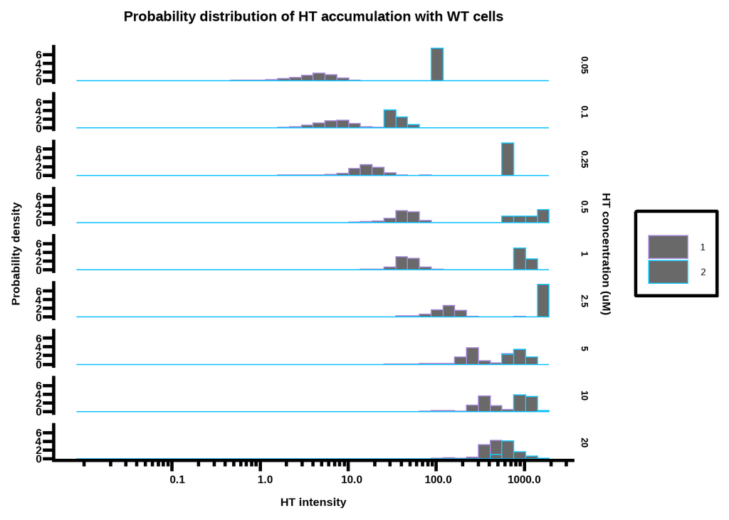

```r
p.acc.clust.WT <-plot.probd(df_acc.WT,"Probability distribution of HT accumulation with WT cells")
```

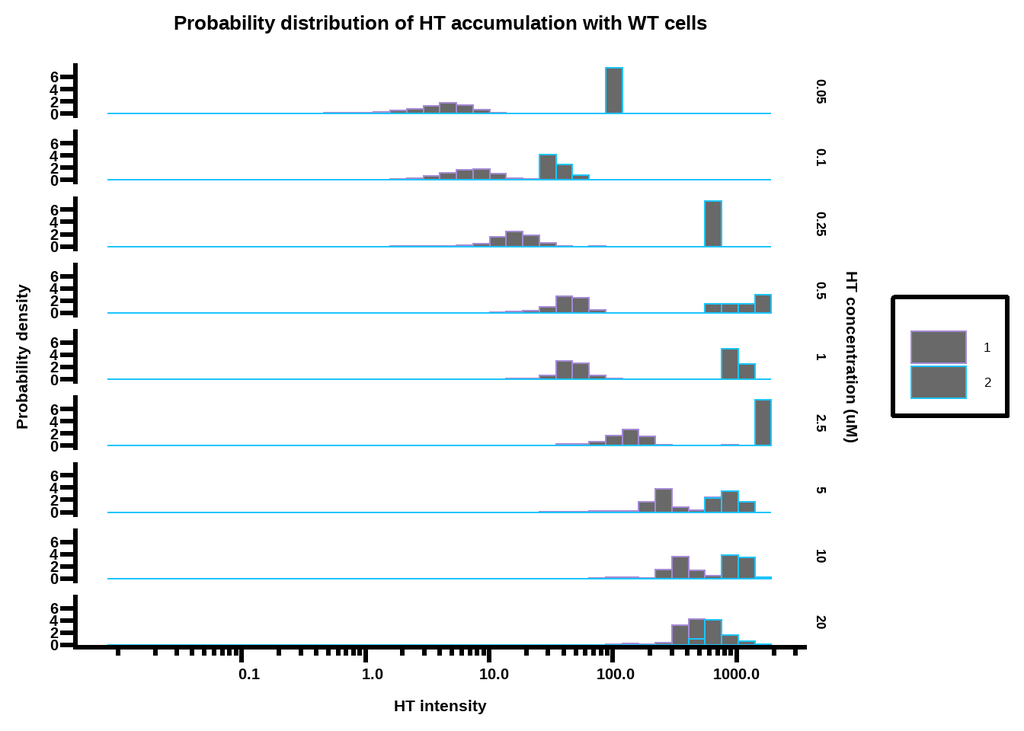

```r
p.acc.clust.WT
```

Label 1 as “dark” and 2 as “bright”

```r
df_acc.WT$H_label[df_acc.WT$H_label  == 1] <- "dark"
df_acc.WT$H_label[df_acc.WT$H_label  == 2] <- "bright"
```

Check the image again to make sure the labels are correct

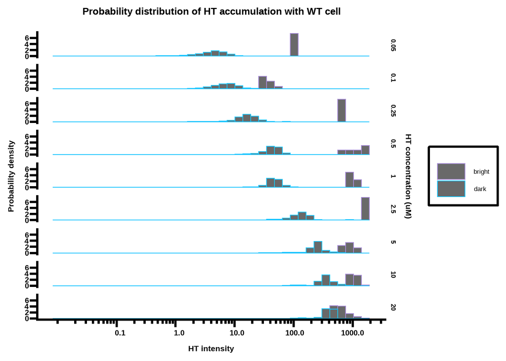

```r
p.clust.acc.WT <- plot.probd(df_acc.WT,"Probability distribution of HT accumulation with WT cell")
```

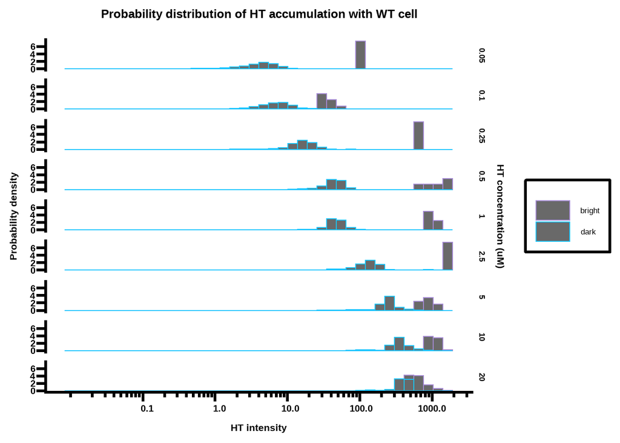

```r
p.clust.acc.WT
```

4.3.3. Result of clustering HT degradation distribution with WT cells

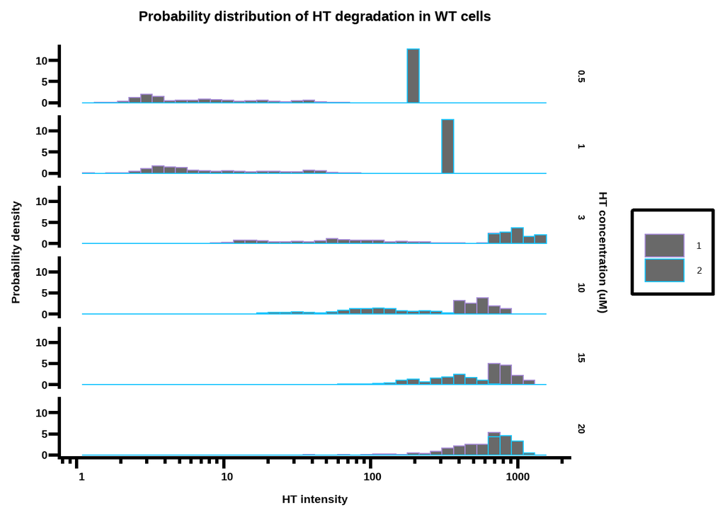

```r
p.clust.deg.WT<- plot.probd(df_deg.WT,"Probability distribution of HT degradation in WT cells" )
```

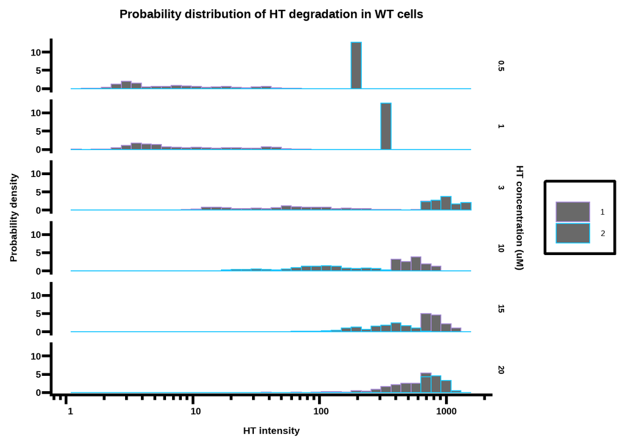

```r
p.clust.deg.WT
```

For the concentrations of 10 and 15uM. The order of label is reversed. The following is to relabel them as 1 for low intensity and 2 for high intensity

```r
df_deg.WT$H_label[(df_deg.WT$H_label == 1) &
                                       (df_deg.WT$HT_Conc_uM == 10|
                                       df_deg.WT$HT_Conc_uM == 15)] <- "bright"
df_deg.WT$H_label[df_deg.WT$H_label == 2 &
                                     (df_deg.WT$HT_Conc_uM == 10|
                                      df_deg.WT$HT_Conc_uM == 15)] <- "dark"
# label the rest
df_deg.WT$H_label[(df_deg.WT$H_label == 1) &
                                       (df_deg.WT$HT_Conc_uM != 10|
                                       df_deg.WT$HT_Conc_uM != 15)] <- "dark"
df_deg.WT$H_label[df_deg.WT$H_label == 2 &
                                     (df_deg.WT$HT_Conc_uM != 10|
                                      df_deg.WT$HT_Conc_uM != 15)] <- "bright"
```

Visualize the distribution again to check the labels

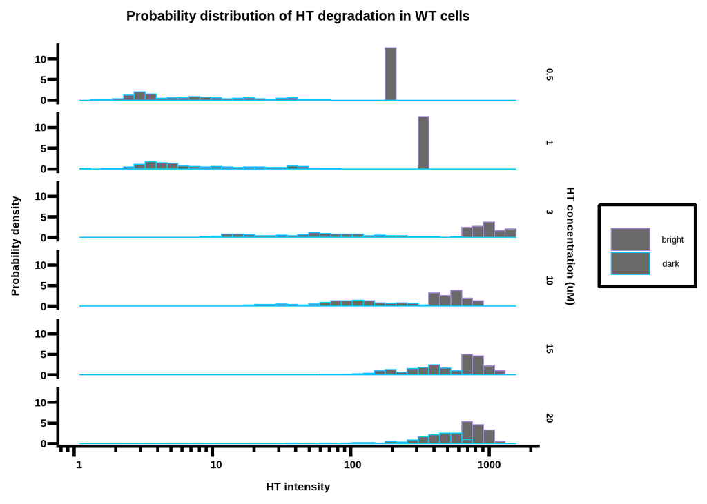

```r
p.clust.deg.WT <- plot.probd(df_deg.WT,"Probability distribution of HT degradation in WT cells")
```

4.3.4. Result of clustering HT degradation distribution with tolC -/-cells

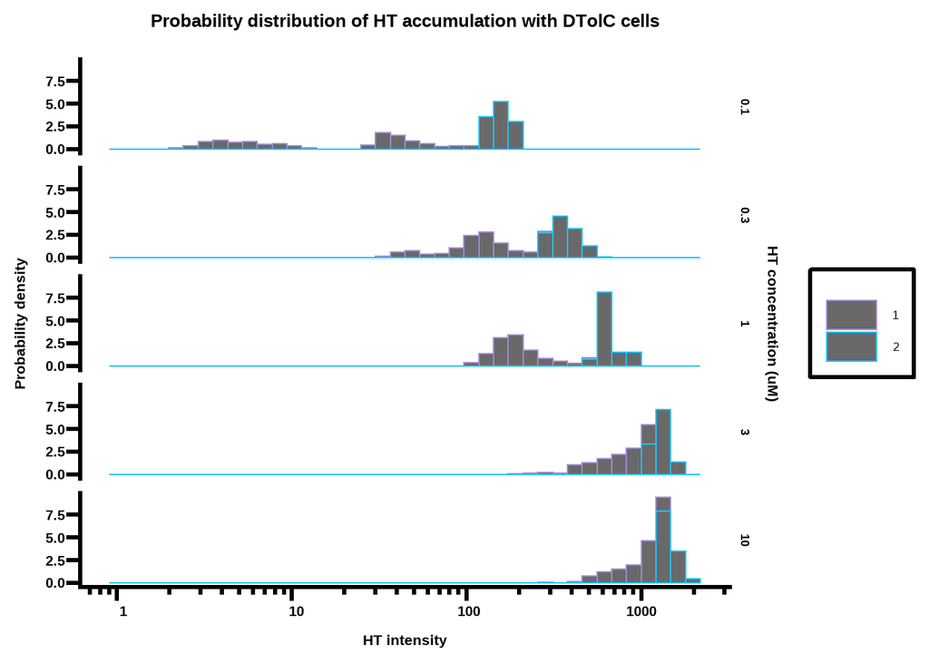

```r
p.clust.deg.DTolC <- plot.probd(df_deg.DTolC, "Probability distribution of HT accumulation with DTolC cells")
```

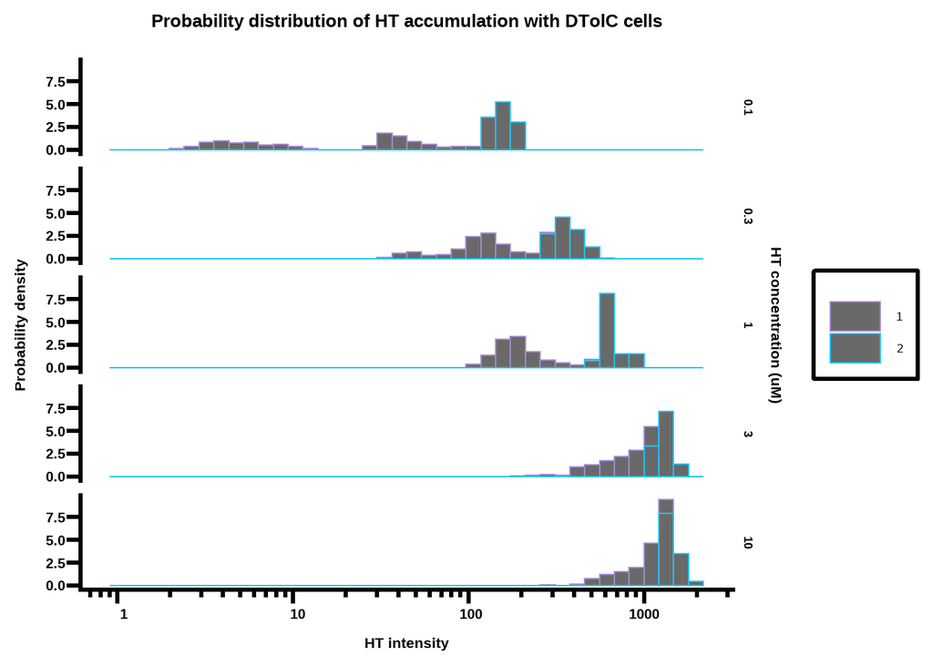

```r
p.clust.deg.DTolC
```

Label 1 as “dark” and 2 as “bright”

```r
df_deg.DTolC$H_label[df_deg.DTolC$H_label  == 1] <- "dark"
df_deg.DTolC$H_label[df_deg.DTolC$H_label  == 2] <- "bright"
```

Double check the labels

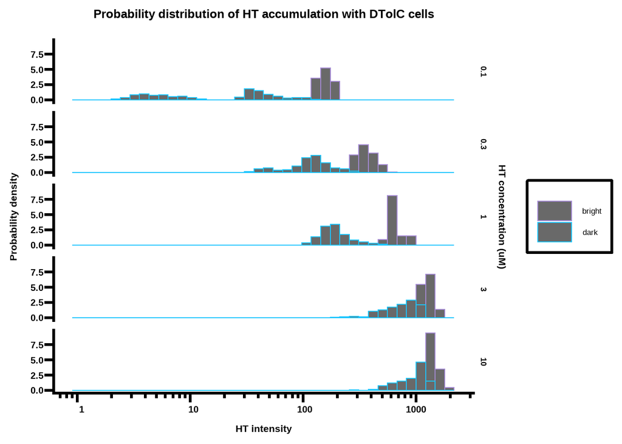

```r
p.clust.deg.DTolC <- plot.probd(df_deg.DTolC, "Probability distribution of HT accumulation with DTolC cells")
```

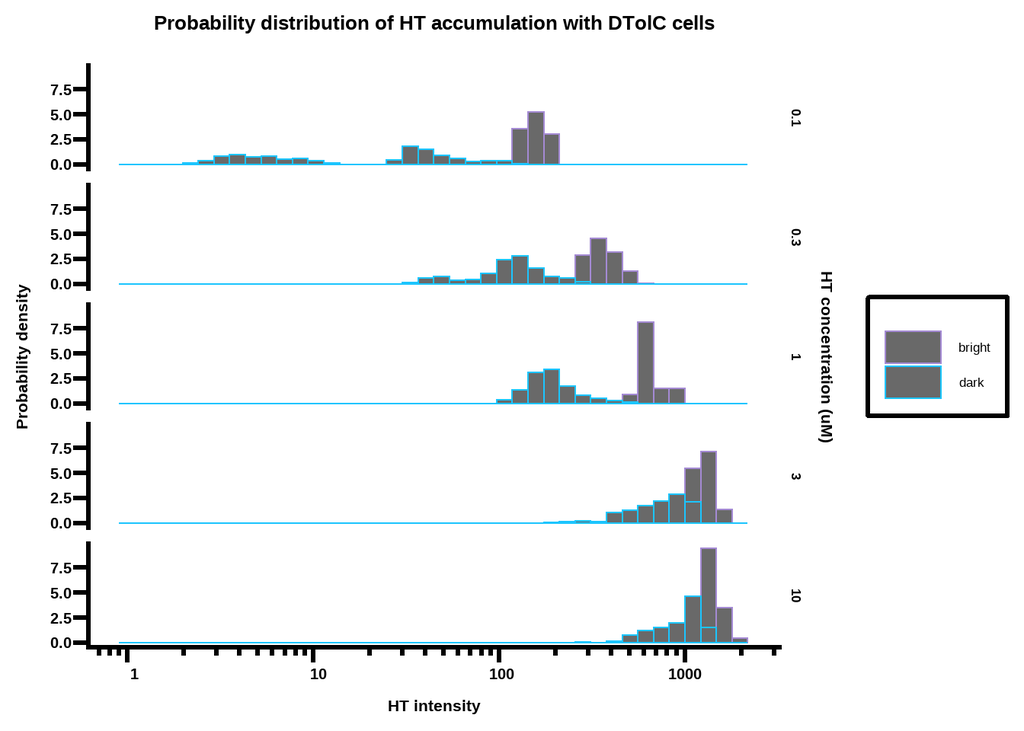

```r
p.clust.deg.DTolC
```

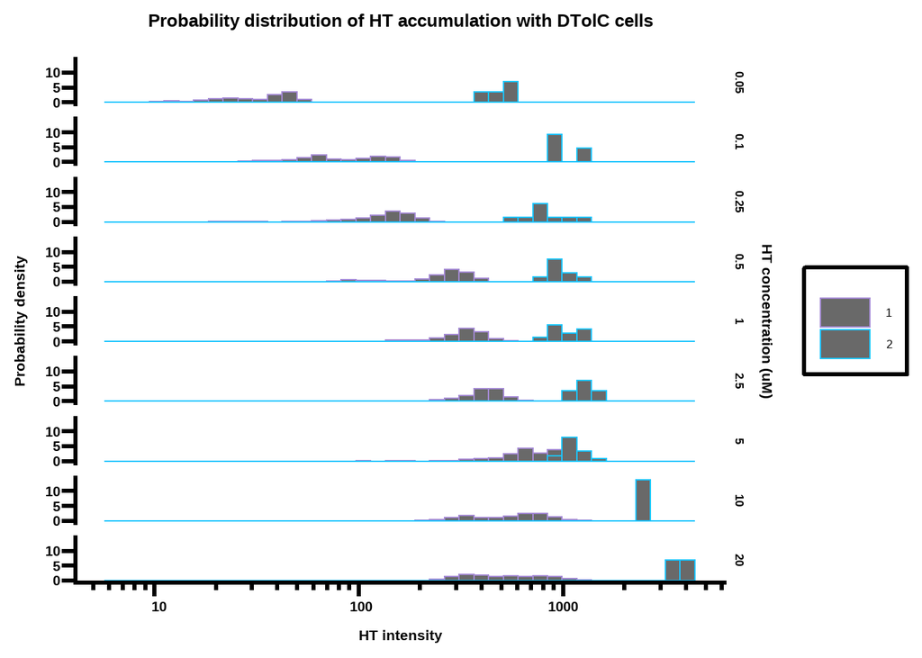

```r
p.clust.acc.DTolC <- plot.probd(df_acc.DTolC, "Probability distribution of HT accumulation with DTolC cells")
```

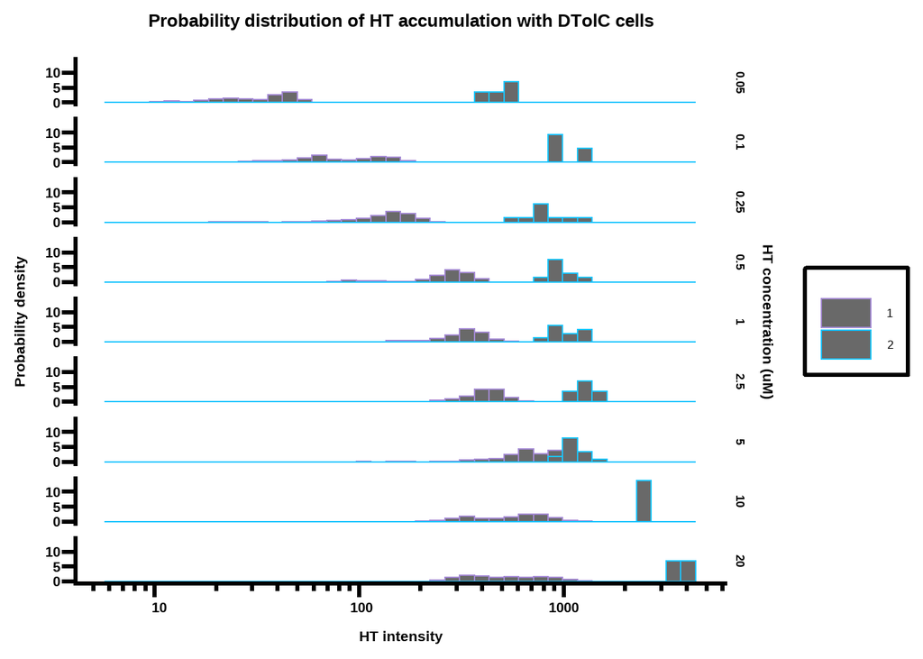

```r
p.clust.acc.DTolC
```

Label 1 as “dark” and 2 as “bright”

```r
df_acc.DTolC$H_label[df_acc.DTolC$H_label  == 1] <- "dark"
df_acc.DTolC$H_label[df_acc.DTolC$H_label  == 2] <- "bright"
```

Double check the labels

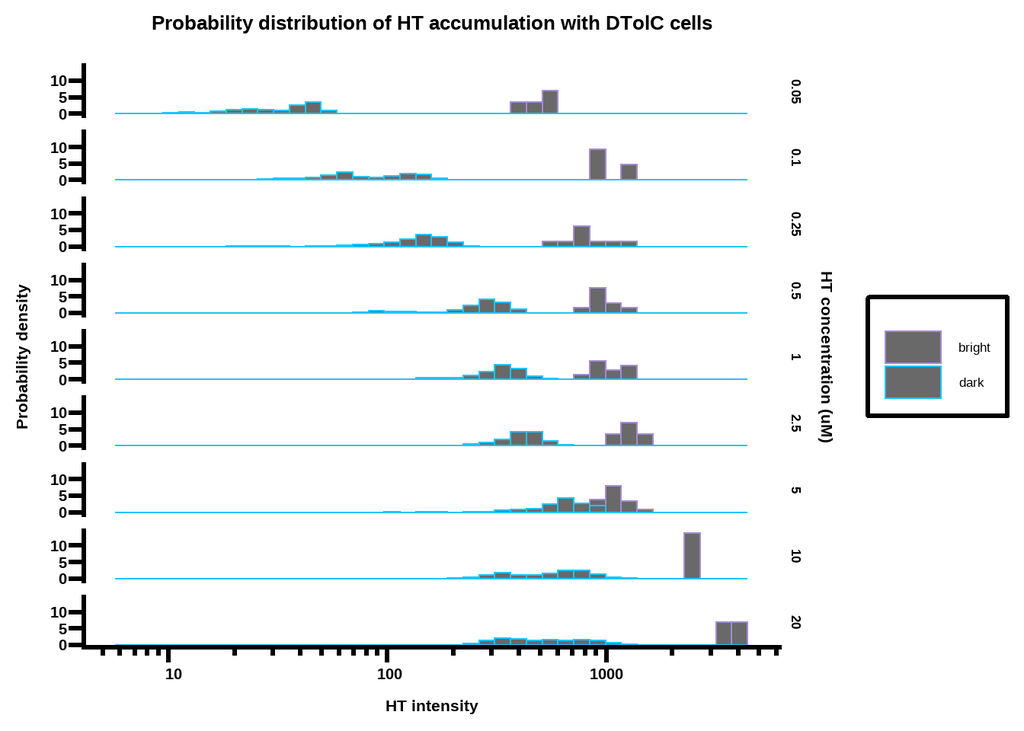

```r
p.clust.acc.DTolC <- plot.probd(df_acc.DTolC, "Probability distribution of HT accumulation with DTolC cells")
```

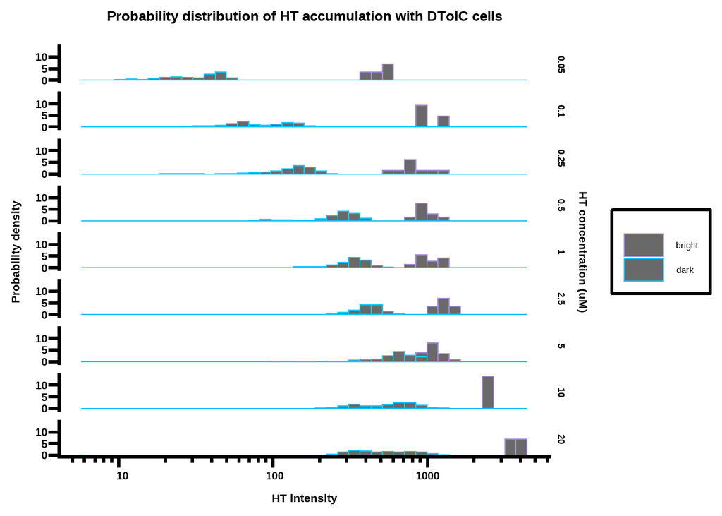

```r
p.clust.acc.DTolC
```

### 5. Quantitative characterization of 2 populations by bimodality index and dip test The bimodality coefficient is b = [(m3^2 + 1)/(m4 + [(3(n-1)2)/((n-2)(n-3))])] where m3 is skewness and m4 is kurtosis. Values of b greater than 0.555 (the value for a uniform population) may indicate bimodal or multimodal marginal distributions. The maximum of 1.0 (obtainedfor the Bernoulli distribution) is obtained for a population with only two distinct values. Very heavy-tailed distributions have small values of b regardless of the number of modes. Hartigan’s dip statistic calculated by taking the maximum difference between the observed distribution of data and a uniform distribution that is chosen to minimize this maximum difference. The idea is that repeated sampling from the uniform (with the sample size of the original data) produces a sampling distribution over these differences; a bimodal (or n-modal) distribution is one in which the HDS is at or greater than the 95th percentile among all sampled values. In other words, as compared to the uniform distribution a multimodal distribution has statistically significant disparities in its distribution function. Thus, the HDS is given to null-hypothesis logic and is inferential; if p < .05, the distribution is considered to be bimodal or multimodal

5.1. Write a function to calculate and store Bimodality index and Dip statistics

```r
# Create a function to store computed values from bimodality and dip.test functions
bimode <- function (df){
BC<- c() # Store BC
DipStat<- c() # Store Dip statistics value
pofDip <-c() # Store p value of Dip statistics
htconc <- unique(df$HT_Conc_uM) # Get list of HT concentrations
HT_Conc_uM <- c() # Store corresponding HT concentrations
for (i in seq_along(htconc)){ # Loop over all the HT concentrations
    data <- df$normed_intensity_ch2[df$HT_Conc_uM == htconc[i]]  # Get data
    BC[i] <- bimodality(data, bs.iter = 2000)
    DipStat[i] <- dip.test(data, 2000)[[1]] # Calculate and store Dip stat
    pofDip[i] <- dip.test(data, 2000)[[2]] # Store p value of Dip stat
    HT_Conc_uM [i] <-htconc[i] # Store corresponding HT concentration
}
    results <-data.frame( HT_Conc_uM, BC, DipStat,pofDip) # Collect results into a dataframe
  return (results)
}
```

5.2. Perform calculations for HT degradation and accumulation with both WT and DTolC strains

```r
df_acc.WT.bc <- bimode(df_acc.WT)
df_deg.WT.bc <- bimode(df_deg.WT)
df_acc.DTolC.bc <- bimode(df_acc.DTolC)
df_deg.DTolC.bc <- bimode(df_deg.DTolC)
```

5.3. Interpret results

```r
# HT accumulation with WT
df_acc.WT.bc
```

```
##   HT_Conc_uM     BC     DipStat pofDip
## 1       0.05 0.0940 0.004845345 1.0000
## 2       0.10 0.9350 0.005859441 1.0000
## 3       0.25 0.3755 0.005267239 1.0000
## 4       0.50 0.0940 0.005131949 0.9965
## 5       1.00 0.6580 0.005145933 0.9995
## 6       2.50 0.9655 0.006284728 1.0000
## 7       5.00 1.0000 0.011241408 0.4790
## 8      10.00 1.0000 0.010117720 0.5690
## 9      20.00 0.9995 0.005952081 1.0000
```

From the table, evidently BC and Dip test do not agree at concentrations 0.1,1,2.5,5,10,20uM. There’s not enough evidence to claim the bimodality. At concentrations 0.05,0.25,0.5 uM , BC and Dip test agree that the distribution is unimodal. Overall, for HT accumulation in WT strain, the distribution is unimodal at tested concentrations

```r
# HT degradation with WT
df_deg.WT.bc
```

```
##   HT_Conc_uM    BC     DipStat pofDip
## 1        0.5 1.000 0.010721094 0.9655
## 2        1.0 0.998 0.009218271 0.9960
## 3        3.0 0.999 0.017315671 0.3730
## 4       10.0 0.918 0.020351367 0.1260
## 5       15.0 0.721 0.021908367 0.0610
## 6       20.0 0.168 0.009703291 1.0000
```

BC and Dip test also disagree on most of tested HT concentrations. While BC indicates that there’s a bimodal distribution for concentrations 0.5, 1,3,10,15 uM, p values of Dip tests suggest that null hypothesis (distribution is unimodal) cannot be rejected. At concentration of 20uM, both BC and Dip test agree that the distribution is unimodal

```r
# HT accumulation with DTolC strain
df_acc.DTolC.bc
```

```
##   HT_Conc_uM     BC     DipStat pofDip
## 1       0.05 1.0000 0.024902976 0.0000
## 2       0.10 1.0000 0.025834835 0.0000
## 3       0.25 0.9990 0.009473968 0.6280
## 4       0.50 1.0000 0.021979093 0.0005
## 5       1.00 0.9850 0.007338817 0.8680
## 6       2.50 0.9395 0.009135790 0.8235
## 7       5.00 0.3155 0.008421842 0.9465
## 8      10.00 1.0000 0.026340160 0.0000
## 9      20.00 0.1565 0.006320591 0.9995
```

On the contrary to WT strain, HT accumulation in DTolC strain shows clear evidences of bimodality. At concentrations of 0.05, 0.1, 0.5, 10uM both BC and Dip test show clear indicators of bimodality. At 0.25, 1, 2.5, uM BC indicates that the distribution is bimodal while Dip test disagrees. At 5, 20uM both tests agree that the distribution is unimodal

```r
# HT degradation with DTolC strain
df_deg.DTolC.bc
```

```
##   HT_Conc_uM     BC     DipStat pofDip
## 1        0.1 1.0000 0.066114534 0.0000
## 2        0.3 1.0000 0.019136010 0.0000
## 3        1.0 0.9950 0.008259148 0.9945
## 4        3.0 0.5455 0.014383118 0.8820
## 5       10.0 0.2970 0.011806642 0.9980
```

At concentrations 0.1 and 0.3uM, both tests agree that the distribution is bimodal. At concentrations 3, 10uM , both tests agree that the distribution is unimodal Only at 1uM, BC supports bimodality while Dip test does not. In the next section, normality tests will be performed to examine whether the underlying distribution is normal. ### 6. Normality tests 6.1. Q-Q plot

```r
# A function for q-q plot
qq <- function(df,tit){
    p<- ggplot(df) +
                            ggnewscale::new_scale_color() +
                             geom_qq_line(aes(sample = normed_intensity_ch2)) +
                            stat_qq(aes(sample = normed_intensity_ch2)) +
                            facet_grid(rows = vars(HT_Conc_uM)) +
                            scale_color_prism(palette = "prism_dark") +
                            scale_y_continuous(name = "Sample quantile") +
                            scale_x_continuous(name = "Theoretical quantile") +
                            labs (title = tit)+
                            guides(y.sec = guide_none("HT concentration (uM)")) +
                            theme_prism(palette = "prism_dark",
                                                        base_size = 16) +
                            theme(legend.background = element_rect(fill = "white"))
    print(p)
}
```

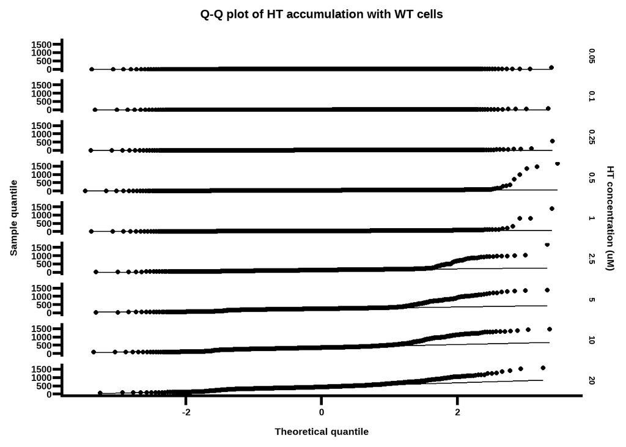

```r
# HT accumulation with WT
p.acc.WT.qq <- qq(df_acc.WT,"Q-Q plot of HT accumulation with WT cells")
```

From the plot, it’s clear that at 0.05,0.1,0.25 uM of HT accumulation, the data fit normal theoretical quantiles very well, indicating underlying normal distribution. The rest of the plots, it is observable that there’s 1 part of the data fit well with theoretical quantiles, while the rest doesn’t, displaying a bimodality

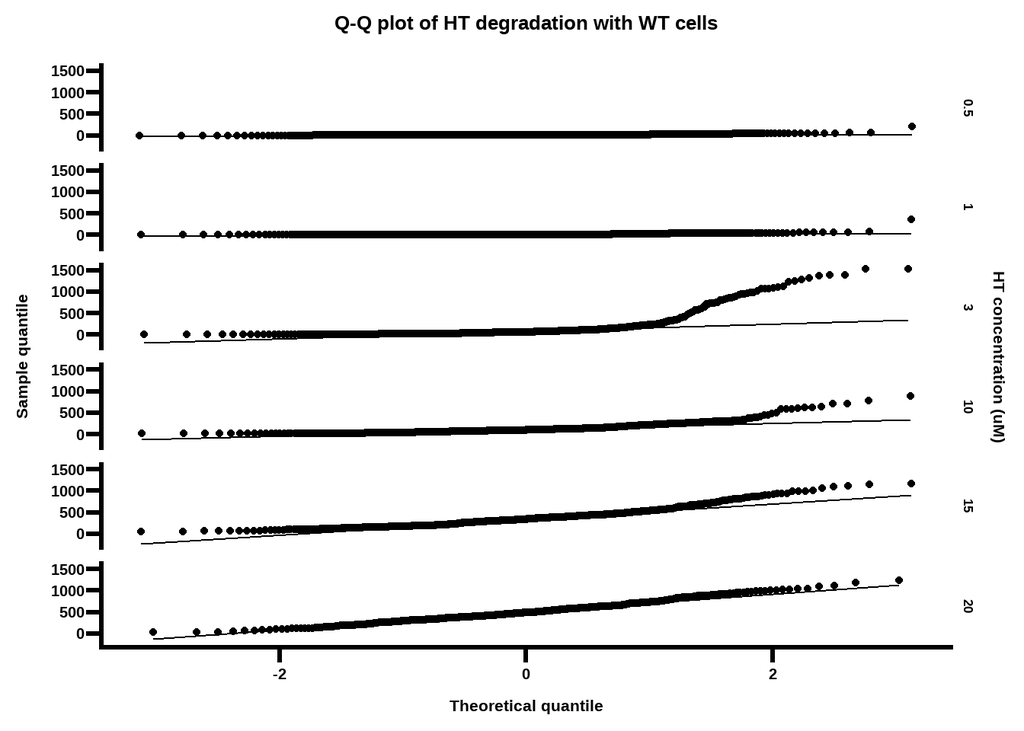

```r
# HT degradation with WT
p.deg.WT.qq <- qq(df_deg.WT,"Q-Q plot of HT degradation with WT cells")
```

At concentrations 0.5, 1 and 20 uM , the sample quantiles fit well with theoretical quantiles, indicating underlying normal distribution. While the rest of the plots, there are apparent deviations from theoretical quantiles.

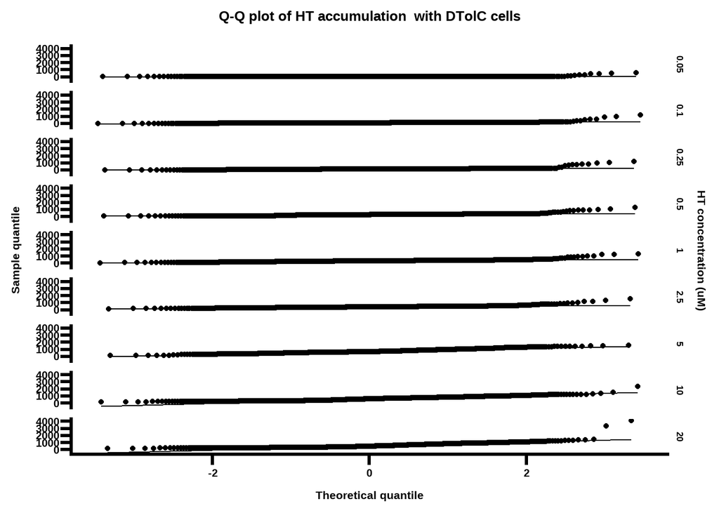

```r
# HT accumulation with DTolC
p.acc.DTolC.qq <- qq(df_acc.DTolC,"Q-Q plot of HT accumulation  with DTolC cells")
```

The majority of the plots fit with theoretical quantiles, while there are still some data points that fall outside of the line. This requires further tests and also suggests a different underlying distribution other than normal.

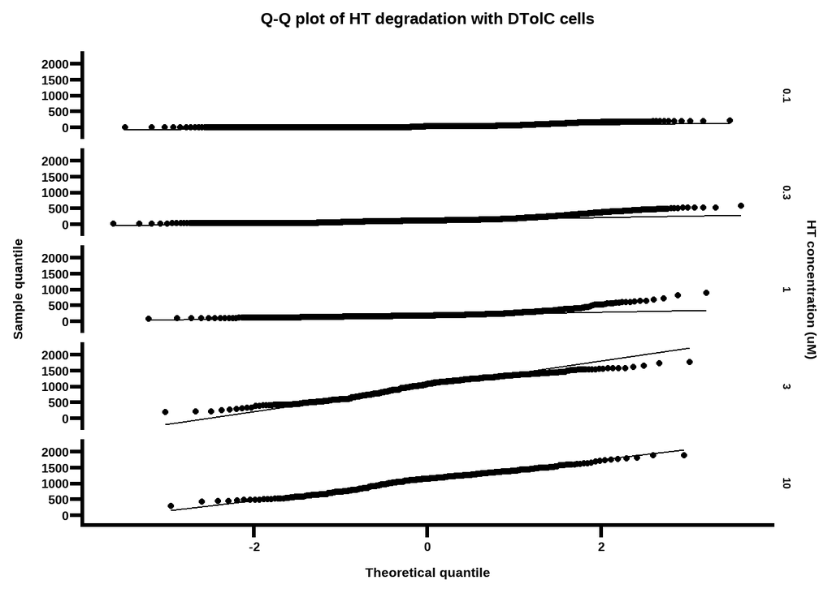

```r
# HT degradation with DTolC
p.deg.DTolC.qq <- qq(df_deg.DTolC,"Q-Q plot of HT degradation with DTolC cells")
```

```r
# A function to perform and store results of Shapiro-Wilk test
shapiro <- function(df){
  htconc <- unique(df$HT_Conc_uM)
  shapiro_stat <- c()
  HT_Conc_uM <- c()
  pvalue <-c()
  for (i in seq_along(htconc)){
    data <- df$normed_intensity_ch2[df$HT_Conc_uM == htconc[i]]
    shapiro_stat[i] <- shapiro.test(data)[[1]]
    pvalue[i] <- shapiro.test(data)[[2]]
    HT_Conc_uM[i] <- htconc[[i]]
  }
  results <- data.frame(shapiro_stat, pvalue, HT_Conc_uM)
  print(results)
  return (results)
}
```

```r
# HT accumulation with WT
df_acc.WT.shap <- shapiro(df_acc.WT)
```

```
##   shapiro_stat       pvalue HT_Conc_uM
## 1    0.6185070 2.321236e-48       0.05
## 2    0.8070194 2.471433e-35       0.10
## 3    0.2432113 3.803580e-61       0.25
## 4    0.1431958 1.317160e-69       0.50
## 5    0.1998372 3.525043e-61       1.00
## 6    0.4915665 9.347278e-49       2.50
## 7    0.6648164 2.045724e-42       5.00
## 8    0.7671729 2.837910e-39      10.00
## 9    0.8875147 4.295024e-25      20.00
```

From the results of the shapiro tests, we can conclude that HT accumulation data with WT strain will not fit normal distribution with >99% confidence

```r
# HT degradation with WT
df_deg.WT.shap <- shapiro(df_deg.WT)
```

```
##   shapiro_stat       pvalue HT_Conc_uM
## 1    0.5869542 1.068583e-34        0.5
## 2    0.4670071 1.383849e-37        1.0
## 3    0.5641602 1.193947e-33        3.0
## 4    0.7586630 2.077043e-27       10.0
## 5    0.9232288 3.775720e-16       15.0
## 6    0.9857248 5.869756e-04       20.0
```

Similarly, we can conclude that HT degradation data with WT strain will not fit normal distribution with >99% confidence

```r
# HT accumulation with DTolC
df_acc.DTolC.shap <- shapiro(df_acc.DTolC)
```

```
##   shapiro_stat       pvalue HT_Conc_uM
## 1    0.3630987 1.228006e-57       0.05
## 2    0.6390205 3.335960e-52       0.10
## 3    0.5768765 4.550593e-49       0.25
## 4    0.8235709 8.887255e-37       0.50
## 5    0.8569393 2.484515e-36       1.00
## 6    0.8354204 1.074665e-32       2.50
## 7    0.9742895 1.408331e-12       5.00
## 8    0.9547400 1.046962e-21      10.00
## 9    0.8129563 8.419901e-35      20.00
```

```r
# HT degradation with DTolC
df_deg.DTolC.shap <- shapiro(df_deg.DTolC)
```

```
##   shapiro_stat       pvalue HT_Conc_uM
## 1    0.7730220 1.082590e-46        0.1
## 2    0.8355196 1.618137e-50        0.3
## 3    0.7273819 1.411370e-33        1.0
## 4    0.9676602 1.015410e-07        3.0
## 5    0.9833820 9.083259e-04       10.0
```

Similar to shapiro tests conducted on WT data, we can conclude that HT accumulation and degradation in DTolC cells do not fit normal distribution with more than 99% confidence.